# CRD Advanced: Contrasts and Multiple Comparisons

Multiple Comparisons and Post-Hoc Tests

Dr. Samuel B Fernandes

2026-01-01

## Learning Objectives

- Understand when to use **planned contrasts** vs. **post-hoc comparisons**
- Apply **orthogonal contrasts** to test specific hypotheses in CRD
- Implement multiple comparison procedures: **Tukey HSD**, **Dunnett’s test**
- Use **emmeans** package for estimating marginal means and contrasts

## Review: Completely Randomized Design (CRD)

**CRD Model:**

$y_{ij} = \mu + \tau_i + \epsilon_{ij}$ or $y_{ij} = \mu_i + \epsilon_{ij}$

**Where:**

- $y_{ij}$ = observation $j$ in treatment $i$
- $\mu$ = overall mean
- $\tau_i$ = effect of treatment $i$
- $\epsilon_{ij} \sim N(0, \sigma^2)$ = random error

**Key assumption:** Experimental units are **homogeneous** (no blocking needed)

## After Significant F-test: What Now?

Significant F-test means:

$$H_0: \mu_1 = \mu_2 = \cdots = \mu_t \text{ is rejected}$$

**At least one mean differs, but which ones?**

Two approaches:

1. **Planned comparisons (contrasts)**: Pre-specified hypotheses
2. **Post-hoc comparisons**: Explore all pairwise differences

## Diagnostic Plots: Check Assumptions First!

Before interpreting ANOVA, **always check assumptions**:

1. **Normality of residuals**: Q-Q plot
2. **Homogeneity of variance**: Residuals vs. Fitted
3. **Independence**: Random assignment in CRD
4. **No extreme outliers**: Leverage plot

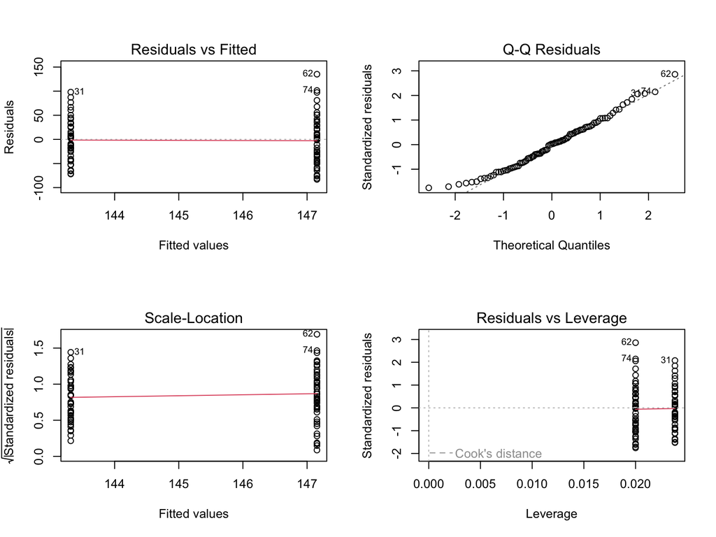

Figure 1: Four diagnostic plots for checking ANOVA assumptions in CRD

```r
# Example: Variety trial
data(archbold.apple, package = "agridat")
apple <- archbold.apple |>
    filter(!is.na(yield)) |>
    mutate(gen = factor(gen))

# Fit CRD model
model_apple <- lm(yield ~ gen, data = apple)

# Create diagnostic plots
par(mfrow = c(2, 2))
plot(model_apple)
par(mfrow = c(1, 1))
```

## Real Data Example: Radon Release Experiment

**Laboratory CRD:** Effect of orifice diameter on radon release

```r
# Load radon data from GitHub
radon_url <- "https://raw.githubusercontent.com/Jaisai0611/CRD-example/main/EX%203.21.csv"
radon_data <- read.csv(radon_url) |>
    pivot_longer(
        cols = starts_with("Radon"),
        names_to = "sample",
        values_to = "radon_pct"
    ) |>
    mutate(
        orifice = factor(Orifice.Diameter),
        response = radon_pct
    ) |>
    dplyr::select(orifice, sample, response)

# Summary statistics by orifice size
radon_data |>
    group_by(orifice) |>
    summarize(
        n = n(),
        mean = mean(response),
        sd = sd(response),
        .groups = "drop"
    ) |>
    knitr::kable(digits = 1)
```

| orifice | n | mean | sd |
| --- | --- | --- | --- |
| 0.37 | 4 | 82.8 | 2.1 |
| 0.51 | 4 | 77.0 | 2.3 |
| 0.71 | 4 | 75.0 | 1.8 |
| 1.02 | 4 | 71.8 | 3.3 |
| 1.4 | 4 | 65.0 | 3.6 |
| 1.99 | 4 | 62.8 | 2.8 |

## Visualize Treatment Effects

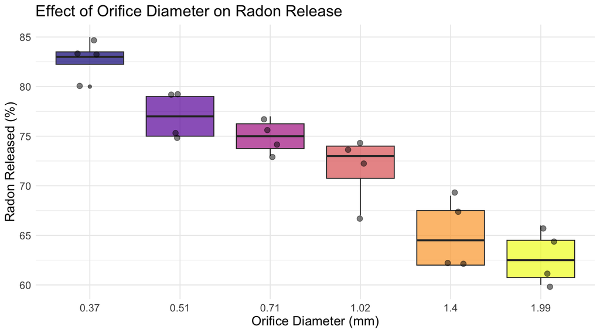

Figure 2: Radon release percentage by orifice diameter

```r
ggplot(radon_data, aes(x = orifice, y = response, fill = orifice)) +
    geom_boxplot(alpha = 0.7) +
    geom_jitter(width = 0.15, alpha = 0.5, size = 2.5) +
    labs(
        title = "Effect of Orifice Diameter on Radon Release",
        x = "Orifice Diameter (mm)",
        y = "Radon Released (%)",
        fill = "Diameter"
    ) +
    scale_fill_viridis_d(option = "plasma") +
    theme_minimal() +
    theme(
        text = element_text(size = 14),
        legend.position = "none"
    )
```

## Fit CRD Model and Check Assumptions

Fit one-way ANOVA model

```r
model_radon <- lm(response ~ orifice, data = radon_data)
```

ANOVA table

```r
anova(model_radon)
```

```
#> Analysis of Variance Table
#>
#> Response: response
#>           Df  Sum Sq Mean Sq F value   Pr(>F)
#> orifice    5 1133.38 226.675  30.852 3.16e-08 ***
#> Residuals 18  132.25   7.347
#> ---
#> Signif. codes:  0 '***' 0.001 '**' 0.01 '*' 0.05 '.' 0.1 ' ' 1
```

Model coefficients

```r
summary(model_radon)
```

```
#>
#> Call:
#> lm(formula = response ~ orifice, data = radon_data)
#>
#> Residuals:
#>    Min     1Q Median     3Q    Max
#>  -4.75  -2.00   0.25   2.00   4.00
#>
#> Coefficients:
#>             Estimate Std. Error t value Pr(>|t|)
#> (Intercept)   82.750      1.355  61.057  < 2e-16 ***
#> orifice0.51   -5.750      1.917  -3.000 0.007685 **
#> orifice0.71   -7.750      1.917  -4.043 0.000762 ***
#> orifice1.02  -11.000      1.917  -5.739 1.93e-05 ***
#> orifice1.4   -17.750      1.917  -9.261 2.87e-08 ***
#> orifice1.99  -20.000      1.917 -10.435 4.62e-09 ***
#> ---
#> Signif. codes:  0 '***' 0.001 '**' 0.01 '*' 0.05 '.' 0.1 ' ' 1
#>
#> Residual standard error: 2.711 on 18 degrees of freedom
#> Multiple R-squared:  0.8955, Adjusted R-squared:  0.8665
#> F-statistic: 30.85 on 5 and 18 DF,  p-value: 3.16e-08
```

## Diagnostic Plots: Radon CRD

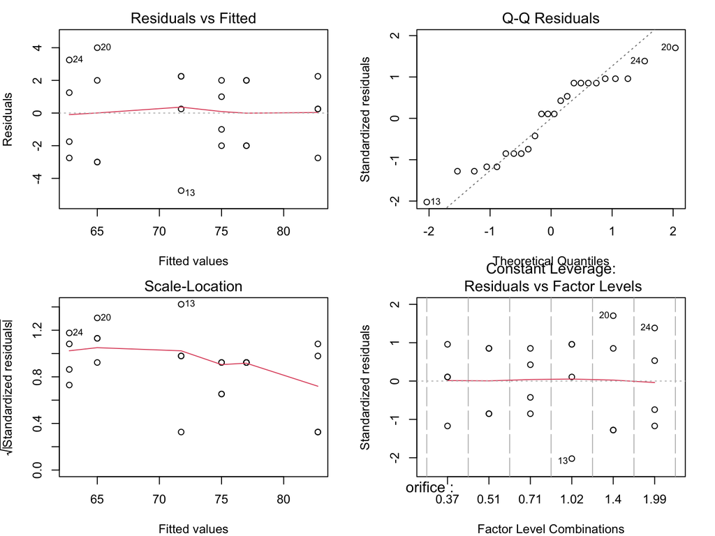

Figure 3: Diagnostic plots for radon release CRD

```r
# Check ANOVA assumptions
par(mfrow = c(2, 2), mar = c(4, 4, 2, 2))
plot(model_radon)
par(mfrow = c(1, 1))
```

## Estimated Marginal Means with emmeans

Calculate estimated marginal means (EMMs)

```r
emm_radon <- emmeans(model_radon, ~orifice)
emm_radon
```

```
#>  orifice emmean   SE df lower.CL upper.CL
#>  0.37      82.8 1.36 18     79.9     85.6
#>  0.51      77.0 1.36 18     74.2     79.8
#>  0.71      75.0 1.36 18     72.2     77.8
#>  1.02      71.8 1.36 18     68.9     74.6
#>  1.4       65.0 1.36 18     62.2     67.8
#>  1.99      62.8 1.36 18     59.9     65.6
#>
#> Confidence level used: 0.95
```

Display with confidence intervals

```r
TukeyHSD(aov(response ~ orifice, data = radon_data))
```

```
#>   Tukey multiple comparisons of means
#>     95% family-wise confidence level
#>
#> Fit: aov(formula = response ~ orifice, data = radon_data)
#>
#> $orifice
#>             diff        lwr         upr     p adj
#> 0.51-0.37  -5.75 -11.841234   0.3412336 0.0707511
#> 0.71-0.37  -7.75 -13.841234  -1.6587664 0.0084181
#> 1.02-0.37 -11.00 -17.091234  -4.9087664 0.0002404
#> 1.4-0.37  -17.75 -23.841234 -11.6587664 0.0000004
#> 1.99-0.37 -20.00 -26.091234 -13.9087664 0.0000001
#> 0.71-0.51  -2.00  -8.091234   4.0912336 0.8968057
#> 1.02-0.51  -5.25 -11.341234   0.8412336 0.1153360
#> 1.4-0.51  -12.00 -18.091234  -5.9087664 0.0000841
#> 1.99-0.51 -14.25 -20.341234  -8.1587664 0.0000089
#> 1.02-0.71  -3.25  -9.341234   2.8412336 0.5513482
#> 1.4-0.71  -10.00 -16.091234  -3.9087664 0.0007059
#> 1.99-0.71 -12.25 -18.341234  -6.1587664 0.0000650
#> 1.4-1.02   -6.75 -12.841234  -0.6587664 0.0249971
#> 1.99-1.02  -9.00 -15.091234  -2.9087664 0.0021152
#> 1.99-1.4   -2.25  -8.341234   3.8412336 0.8432736
```

## Visualize Estimated Marginal Means

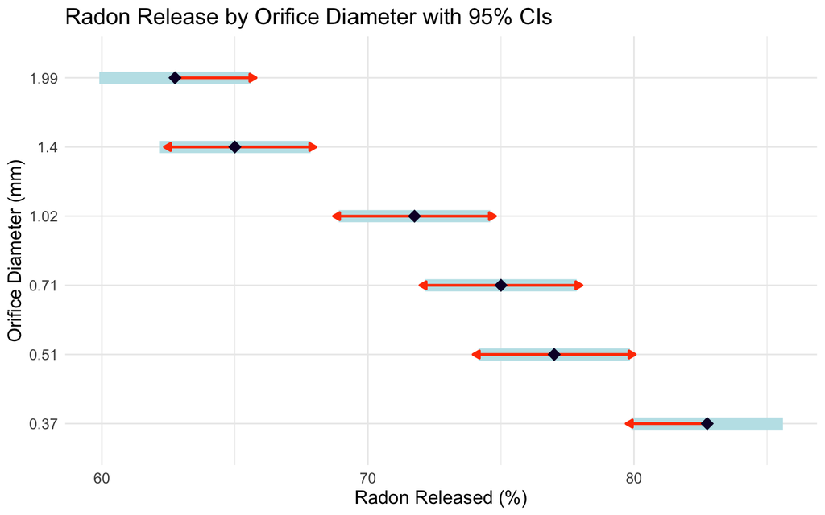

Figure 4: Estimated marginal means with 95% confidence intervals

```r
# Plot EMMs with CIs
plot(emm_radon, comparisons = TRUE) +
    labs(
        title = "Radon Release by Orifice Diameter with 95% CIs",
        x = "Radon Released (%)",
        y = "Orifice Diameter (mm)"
    ) +
    theme_minimal() +
    theme(text = element_text(size = 13))
```

## Planned Contrasts: Testing Specific Hypotheses

**Scientific questions** can be translated into **contrasts**.

Example with 4 NPK application methods:

1. No NPK (control)
2. NPK in January (plowed)
3. NPK in January (broadcast)
4. NPK in April (broadcast)

**Research questions → Contrasts:**

- $C_1$: Does NPK help? (Control vs. all NPK treatments)
- $C_2$: Does timing matter? (January vs. April application)
- $C_3$: Does method matter? (Plowed vs. broadcast within January)

## Contrast Coefficients: How to Construct

**Treatments:**

1. No NPK (Control)
2. Jan (plowed)
3. Jan (broadcast)
4. Apr (broadcast)

**Contrasts:**

| Contrast | 1 | 2 | 3 | 4 |
| --- | --- | --- | --- | --- |
| $C_1$: Control vs NPK | +3 | -1 | -1 | -1 |
| $C_2$: Jan vs Apr | 0 | +1 | +1 | -2 |
| $C_3$: Plow vs Broadcast | 0 | +1 | -1 | 0 |

**Rules for contrast coefficients:**

1. Must sum to zero: $\sum c_i = 0$
2. For orthogonality: $\sum c_{1i} \cdot c_{2i} = 0$

## Simulated Example: NPK Fertilizer Trial

```r
# Create simulated but realistic NPK application data
set.seed(2026)
npk_data <- data.frame(
    treatment = factor(rep(c("Control", "Jan_Plow", "Jan_Broadcast", "Apr_Broadcast"), each = 8),
        levels = c("Control", "Jan_Plow", "Jan_Broadcast", "Apr_Broadcast")
    ),
    block = factor(rep(1:8, 4)),
    yield = c(
        rnorm(8, 45, 5), # Control: lower yield
        rnorm(8, 62, 5), # Jan plowed: best
        rnorm(8, 58, 5), # Jan broadcast: good
        rnorm(8, 55, 6) # Apr broadcast: moderate
    )
)

# Summary by treatment
npk_data |>
    group_by(treatment) |>
    summarize(
        n = n(),
        mean = mean(yield),
        sd = sd(yield),
        .groups = "drop"
    ) |>
    knitr::kable(digits = 1)
```

| treatment | n | mean | sd |
| --- | --- | --- | --- |
| Control | 8 | 41.6 | 4.7 |
| Jan_Plow | 8 | 60.0 | 5.4 |
| Jan_Broadcast | 8 | 58.2 | 4.5 |
| Apr_Broadcast | 8 | 59.3 | 5.6 |

## Visualize NPK Trial Data

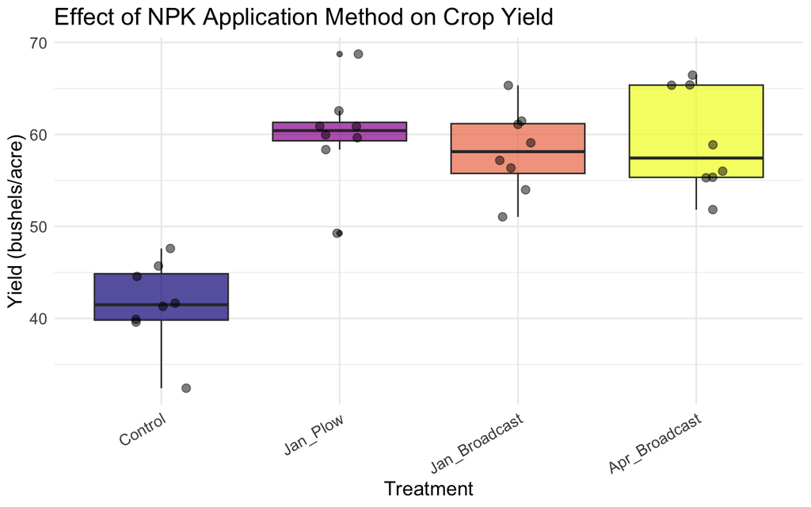

Figure 5: Crop yield by NPK application method

```r
ggplot(npk_data, aes(x = treatment, y = yield, fill = treatment)) +
    geom_boxplot(alpha = 0.7) +
    geom_jitter(width = 0.15, alpha = 0.5, size = 2.5) +
    labs(
        title = "Effect of NPK Application Method on Crop Yield",
        x = "Treatment",
        y = "Yield (bushels/acre)",
        fill = "Treatment"
    ) +
    scale_fill_viridis_d(option = "plasma") +
    theme_minimal() +
    theme(
        text = element_text(size = 14),
        axis.text.x = element_text(angle = 30, hjust = 1),
        legend.position = "none"
    )
```

## Implementing Contrasts with emmeans

```r
# Fit CRD model
model_npk <- lm(yield ~ treatment, data = npk_data)

# Get estimated marginal means
emm_npk <- emmeans(model_npk, ~treatment)

# Define contrasts as a list
contrast_list <- list(
    "Control vs NPK" = c(3, -1, -1, -1) / 3, # Divide to get average
    "Jan vs Apr" = c(0, 1, 1, -2) / 2, # Compare averages
    "Plow vs Broadcast" = c(0, 1, -1, 0) # Simple comparison
)

# Test contrasts
contrast_results <- contrast(emm_npk, contrast_list)
print(contrast_results)
```

```
#>  contrast          estimate   SE df t.ratio p.value
#>  Control vs NPK     -17.580 2.07 28  -8.475  <.0001
#>  Jan vs Apr          -0.205 2.20 28  -0.093  0.9265
#>  Plow vs Broadcast    1.847 2.54 28   0.727  0.4734
```

```r
# With confidence intervals
confint(contrast_results)
```

```
#>  contrast          estimate   SE df lower.CL upper.CL
#>  Control vs NPK     -17.580 2.07 28   -21.83   -13.33
#>  Jan vs Apr          -0.205 2.20 28    -4.71     4.30
#>  Plow vs Broadcast    1.847 2.54 28    -3.36     7.05
#>
#> Confidence level used: 0.95
```

## Visualize Contrast Results

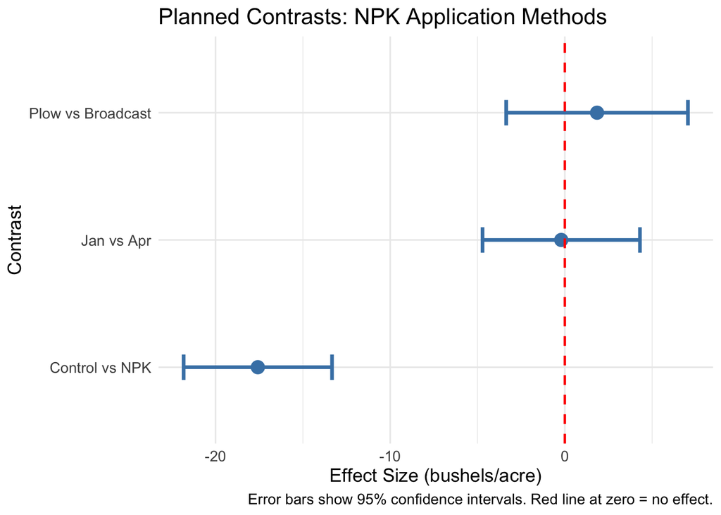

Figure 6: Contrast estimates with 95% confidence intervals

```r
# Plot contrasts with confidence intervals
contrast_df <- confint(contrast_results) |> as.data.frame()
if (!all(c("lower.CL", "upper.CL") %in% names(contrast_df))) {
    contrast_df <- contrast_df |>
        mutate(
            lower.CL = estimate - 1.96 * SE,
            upper.CL = estimate + 1.96 * SE
        )
}

contrast_df |>
    ggplot(aes(x = contrast, y = estimate)) +
    geom_point(size = 4, color = "steelblue") +
    geom_errorbar(aes(ymin = lower.CL, ymax = upper.CL),
        width = 0.2, linewidth = 1.2, color = "steelblue"
    ) +
    geom_hline(yintercept = 0, linetype = "dashed", color = "red", linewidth = 0.8) +
    coord_flip() +
    labs(
        title = "Planned Contrasts: NPK Application Methods",
        x = "Contrast",
        y = "Effect Size (bushels/acre)",
        caption = "Error bars show 95% confidence intervals. Red line at zero = no effect."
    ) +
    theme_minimal() +
    theme(text = element_text(size = 13))
```

## Post-Hoc Comparisons: Multiple Testing Problem

Use post-hoc tests when:

- No pre-planned hypotheses
- Exploratory analysis
- Want to compare **all pairs** of treatments

**Problem: Familywise Error Rate**

$$\alpha_{familywise} = 1 - (1 - \alpha)^k$$

where $k$ = number of comparisons

**Example:** 5 treatments → ${5 \choose 2} = 10$ pairwise comparisons

- Without adjustment: $\alpha_{FW} = 1 - (0.95)^{10} = 0.40$
- **40% chance of at least one false positive!**

**Terminology:** Familywise error rate and **experimentwise error rate** are the same thing—the probability of making at least one Type I error across all comparisons in the experiment.

## Tukey’s Honest Significant Difference (HSD)

**Most common post-hoc test for all pairwise comparisons**

$$HSD = q_{\alpha, t, df_{error}} \times \sqrt{\frac{MS_{Error}}{n}}$$

- $q$ = studentized range statistic (not t-distribution!)
- $t$ = number of treatments
- Properly controls familywise error rate at $\alpha$

**Properties:**

- Conservative (low Type I error)
- Good for balanced or nearly balanced designs
- Compares all treatment pairs

## Tukey HSD with emmeans: Compact Letter Display

Pairwise comparisons with Tukey adjustment

```r
tukey_results <- pairs(emm_npk, adjust = "tukey")
tukey_results
```

```
#>  contrast                      estimate   SE df t.ratio p.value
#>  Control - Jan_Plow             -18.435 2.54 28  -7.256  <.0001
#>  Control - Jan_Broadcast        -16.589 2.54 28  -6.530  <.0001
#>  Control - Apr_Broadcast        -17.717 2.54 28  -6.974  <.0001
#>  Jan_Plow - Jan_Broadcast         1.847 2.54 28   0.727  0.8855
#>  Jan_Plow - Apr_Broadcast         0.718 2.54 28   0.283  0.9919
#>  Jan_Broadcast - Apr_Broadcast   -1.128 2.54 28  -0.444  0.9702
#>
#> P value adjustment: tukey method for comparing a family of 4 estimates
```

**More intuitive way to present multiple comparisons:**

```r
cld_tukey <- cld(emm_npk, adjust = "tukey", Letters = letters)
cld_tukey |>
    as.data.frame() |>
    knitr::kable(digits = 1)
```

|  | treatment | emmean | SE | df | lower.CL | upper.CL | .group |
| --- | --- | --- | --- | --- | --- | --- | --- |
| 1 | Control | 41.6 | 1.8 | 28 | 36.8 | 46.4 | a |
| 3 | Jan_Broadcast | 58.2 | 1.8 | 28 | 53.4 | 63.0 | b |
| 4 | Apr_Broadcast | 59.3 | 1.8 | 28 | 54.5 | 64.1 | b |
| 2 | Jan_Plow | 60.0 | 1.8 | 28 | 55.3 | 64.8 | b |

**Reading CLDs:** Treatments that share a letter are **not significantly different**. Treatments with completely different letters **are significantly different**.

For example:

- Treatments marked “a” and “ab” share the letter “a”, so they’re not significantly different
- Treatments marked “a” and “c” share no letters, so they ARE significantly different

## Visualize Tukey Results with Compact Letters

**Compact Letter Display Table:**

|  | treatment | emmean | SE | df | lower.CL | upper.CL | .group |
| --- | --- | --- | --- | --- | --- | --- | --- |
| 1 | Control | 41.6 | 1.8 | 28 | 36.8 | 46.4 | a |
| 3 | Jan_Broadcast | 58.2 | 1.8 | 28 | 53.4 | 63.0 | b |
| 4 | Apr_Broadcast | 59.3 | 1.8 | 28 | 54.5 | 64.1 | b |
| 2 | Jan_Plow | 60.0 | 1.8 | 28 | 55.3 | 64.8 | b |

**How to read CLDs:**

- Treatments with **same letters** = not significantly different
- Treatments with **no shared letters** = significantly different
- Example: “a” vs “c” = different; “ab” vs “b” = same letter “b” = not different

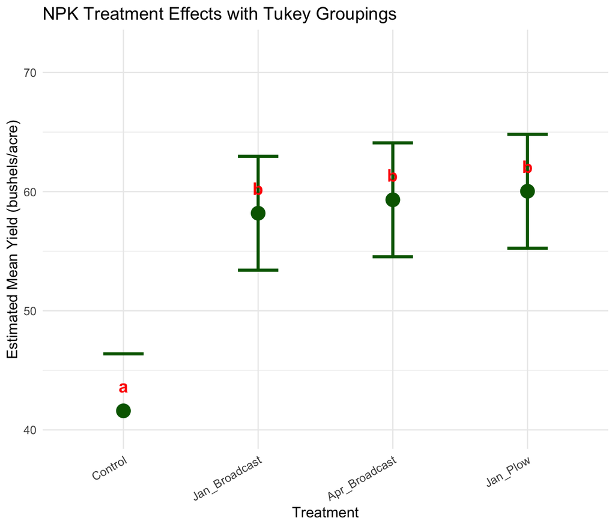

Figure 7: Treatment means with 95% CI and Tukey HSD groups

```r
# Combine EMMs with CLD letters for plotting
cld_df <- cld_tukey |>
    as.data.frame() |>
    mutate(treatment = factor(treatment, levels = treatment))

ggplot(cld_df, aes(x = treatment, y = emmean)) +
    geom_point(size = 5, color = "darkgreen") +
    geom_errorbar(aes(ymin = lower.CL, ymax = upper.CL),
        width = 0.3, linewidth = 1.2, color = "darkgreen"
    ) +
    geom_text(aes(label = str_trim(.group)),
        vjust = -1.5, size = 5, fontface = "bold", color = "red"
    ) +
    labs(
        title = "NPK Treatment Effects with Tukey Groupings",
        x = "Treatment",
        y = "Estimated Mean Yield (bushels/acre)"
    ) +
    scale_y_continuous(limits = c(40, 72)) +
    theme_minimal() +
    theme(
        text = element_text(size = 12),
        axis.text.x = element_text(angle = 30, hjust = 1)
    )
```

## Dunnett’s Test: Compare Treatments to Control

**Use when:** You have a **control** and want to compare all treatments to it

$$d = t_{Dunnett} \times \sqrt{\frac{2 \times MS_{Error}}{n}}$$

**Advantages over Tukey:**

- More **powerful** for control vs. treatment comparisons
- Doesn’t “waste” comparisons on treatment-treatment pairs
- Still controls familywise error rate

**Common in agriculture:** Herbicide trials, variety comparisons to standard

## Dunnett’s Test Implementation

```r
# Dunnett's test: all treatments vs Control
# Control must be the reference level (first level of factor)
dunnett_results <- contrast(emm_npk, method = "trt.vs.ctrl", adjust = "dunnett")
dunnett_results |>
    as.data.frame() |>
    knitr::kable(digits = 2)
```

| contrast | estimate | SE | df | t.ratio | p.value |
| --- | --- | --- | --- | --- | --- |
| Jan_Plow - Control | 18.44 | 2.54 | 28 | 7.26 | 0 |
| Jan_Broadcast - Control | 16.59 | 2.54 | 28 | 6.53 | 0 |
| Apr_Broadcast - Control | 17.72 | 2.54 | 28 | 6.97 | 0 |

```r
# With confidence intervals
confint(dunnett_results) |>
    as.data.frame() |>
    knitr::kable(digits = 2)
```

| contrast | estimate | SE | df | lower.CL | upper.CL |
| --- | --- | --- | --- | --- | --- |
| Jan_Plow - Control | 18.44 | 2.54 | 28 | 12.09 | 24.78 |
| Jan_Broadcast - Control | 16.59 | 2.54 | 28 | 10.24 | 22.93 |
| Apr_Broadcast - Control | 17.72 | 2.54 | 28 | 11.37 | 24.06 |

## Alternative: rstatix for Tidy Workflows

**Modern tidyverse-friendly approach using rstatix:**

```r
# Complete workflow: emmeans_test() - pipe-friendly!
rstatix_results <- npk_data |>
    emmeans_test(yield ~ treatment, p.adjust.method = "tukey")

# Display key columns
rstatix_results |>
    select(term, .y., group1, group2, statistic, p, p.adj, p.adj.signif) |>
    knitr::kable(digits = 3)
```

| term | .y. | group1 | group2 | statistic | p | p.adj | p.adj.signif |
| --- | --- | --- | --- | --- | --- | --- | --- |
| treatment | yield | Control | Jan_Plow | -7.256 | 0.000 | 0.000 | **** |
| treatment | yield | Control | Jan_Broadcast | -6.530 | 0.000 | 0.000 | **** |
| treatment | yield | Control | Apr_Broadcast | -6.974 | 0.000 | 0.000 | **** |
| treatment | yield | Jan_Plow | Jan_Broadcast | 0.727 | 0.473 | 0.979 | ns |
| treatment | yield | Jan_Plow | Apr_Broadcast | 0.283 | 0.779 | 1.000 | ns |
| treatment | yield | Jan_Broadcast | Apr_Broadcast | -0.444 | 0.660 | 0.998 | ns |

**Tip**

**Why rstatix?** Integrates seamlessly with dplyr pipes and returns tidy data frames (not emmGrid objects). Perfect for automated reporting and further data manipulation.

## Alternative Approach: rstatix tukey_hsd()

**Even simpler for pairwise comparisons:**

```r
# rstatix provides a simple tukey_hsd() function
npk_tukey <- npk_data |>
    tukey_hsd(yield ~ treatment)

# Display pairwise comparison results
npk_tukey |>
    select(group1, group2, estimate, conf.low, conf.high, p.adj, p.adj.signif) |>
    knitr::kable(digits = 2)
```

| group1 | group2 | estimate | conf.low | conf.high | p.adj | p.adj.signif |
| --- | --- | --- | --- | --- | --- | --- |
| Control | Jan_Plow | 18.44 | 11.50 | 25.37 | 0.00 | **** |
| Control | Jan_Broadcast | 16.59 | 9.65 | 23.53 | 0.00 | **** |
| Control | Apr_Broadcast | 17.72 | 10.78 | 24.65 | 0.00 | **** |
| Jan_Plow | Jan_Broadcast | -1.85 | -8.78 | 5.09 | 0.89 | ns |
| Jan_Plow | Apr_Broadcast | -0.72 | -7.65 | 6.22 | 0.99 | ns |
| Jan_Broadcast | Apr_Broadcast | 1.13 | -5.81 | 8.06 | 0.97 | ns |

**What rstatix provides:** Pairwise comparisons with p-values and significance stars (*, **, ***).

**Key advantages:**

- Pipe-friendly syntax fits tidyverse workflows
- Output is already a data frame (no conversion needed)
- Great for students who prefer dplyr-style code

**Important:** For CLDs, use `emmeans::cld()` as shown in the previous slide.

## ggpubr: Publication-Ready Comparison Plots

**Complete tidyverse + ggpubr workflow:**

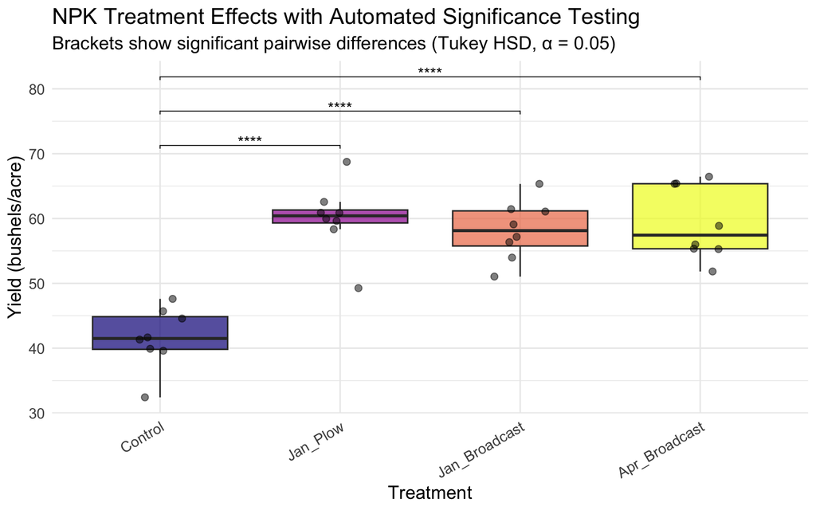

Figure 8: NPK treatment comparison with ggpubr automated annotations

```r
# Step 1: Run statistical test using rstatix
pwc <- npk_data |>
    emmeans_test(yield ~ treatment, p.adjust.method = "tukey")

# Step 2: Prepare positions for brackets
pwc <- pwc |> add_xy_position(x = "treatment")

# Step 3: Create plot with automated significance brackets
ggplot(npk_data, aes(x = treatment, y = yield, fill = treatment)) +
    geom_boxplot(alpha = 0.7, outlier.shape = NA) +
    geom_jitter(width = 0.15, alpha = 0.5, size = 2) +
    # Step 4: Add significance brackets automatically
    stat_pvalue_manual(pwc,
        hide.ns = TRUE, label = "p.adj.signif",
        tip.length = 0.01, step.increase = 0.05
    ) +
    labs(
        title = "NPK Treatment Effects with Automated Significance Testing",
        subtitle = "Brackets show significant pairwise differences (Tukey HSD, α = 0.05)",
        x = "Treatment",
        y = "Yield (bushels/acre)",
        fill = "Treatment"
    ) +
    scale_fill_viridis_d(option = "plasma") +
    theme_minimal() +
    theme(
        text = element_text(size = 13),
        axis.text.x = element_text(angle = 30, hjust = 1),
        legend.position = "none"
    )
```

**Note**

**ggpubr advantage:** Automatically adds significance brackets to plots—perfect for presentations and publications. Uses rstatix output directly!

## Comparison of Adjustment Methods

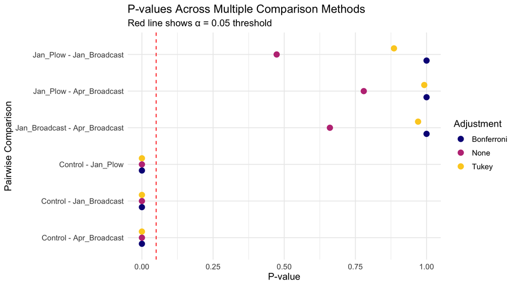

Figure 9: P-values across multiple comparison methods

```r
# Compare different adjustment methods
methods_comparison <- list(
    Tukey = as.data.frame(pairs(emm_npk, adjust = "tukey")),
    Bonferroni = as.data.frame(pairs(emm_npk, adjust = "bonferroni")),
    None = as.data.frame(pairs(emm_npk, adjust = "none")) # Fisher's LSD
) |>
    bind_rows(.id = "method")

# Plot p-values
methods_comparison |>
    as.data.frame() |>
    ggplot(aes(x = contrast, y = p.value, color = method, group = method)) +
    geom_point(size = 3, position = position_dodge(width = 0.5)) +
    geom_hline(yintercept = 0.05, linetype = "dashed", color = "red") +
    coord_flip() +
    labs(
        title = "P-values Across Multiple Comparison Methods",
        subtitle = "Red line shows α = 0.05 threshold",
        x = "Pairwise Comparison",
        y = "P-value",
        color = "Adjustment"
    ) +
    scale_color_viridis_d(option = "plasma", end = 0.9) +
    theme_minimal() +
    theme(text = element_text(size = 12))
```

## Choosing the Right Method: Decision Guide

**Planned Contrasts**

- ✓ Pre-specified hypotheses
- ✓ Most statistical power
- ✓ Clear biological questions
- ✓ Orthogonal when possible

**Example:** Control vs. treatments, dose-response trends

**Tukey HSD**

- ✓ All pairwise comparisons
- ✓ Balanced designs
- ✓ Conservative protection

**Dunnett’s Test**

- ✓ Compare all to control
- ✓ More power than Tukey for this case
- ✓ Common in applied trials

**Tip**

**Best practice:** Plan contrasts during experimental design. Use post-hoc only for exploratory follow-up.

## Alternative: easystats for Comprehensive ANOVA Reporting

**Modern integrated approach using the easystats ecosystem:**

```r
# Install easystats if needed: install.packages("easystats")
library(performance)
library(parameters)
library(effectsize)
library(report)

# Check model assumptions with performance::check_model()
check_model(model_npk, check = c("normality", "homogeneity", "qq", "outliers"))
```

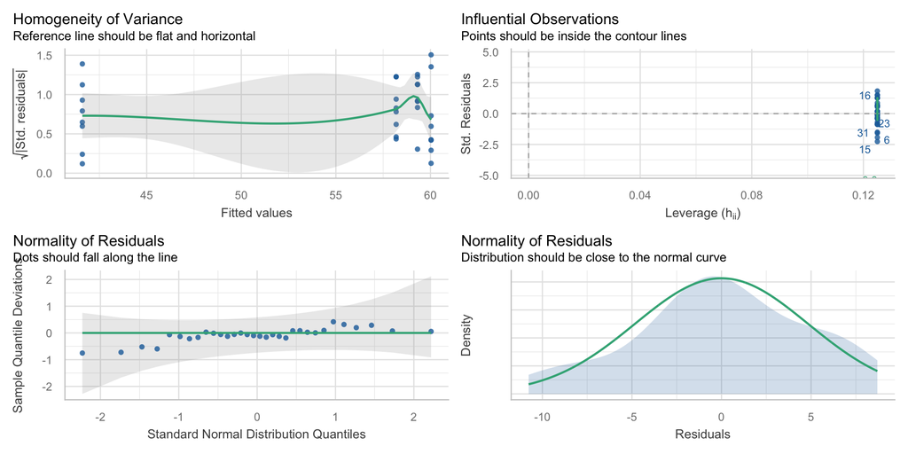

## easystats: Model Parameters & Effect Sizes

```r
# Extract model parameters with confidence intervals and standardization
model_parameters(model_npk, effects = "fixed", ci = 0.95)
```

```
#> Parameter                 | Coefficient |   SE |         95% CI | t(28) |      p
#> --------------------------------------------------------------------------------
#> (Intercept)               |       41.60 | 1.80 | [37.92, 45.28] | 23.16 | < .001
#> treatment [Jan_Plow]      |       18.44 | 2.54 | [13.23, 23.64] |  7.26 | < .001
#> treatment [Jan_Broadcast] |       16.59 | 2.54 | [11.38, 21.79] |  6.53 | < .001
#> treatment [Apr_Broadcast] |       17.72 | 2.54 | [12.51, 22.92] |  6.97 | < .001
```

```r
# Calculate effect sizes - proportion of variance explained by treatment
# η² (eta-squared): Proportion of total variance explained (biased, overestimates)
# ω² (omega-squared): Less biased estimate, adjusts for sample size
# ε² (epsilon-squared): Alternative unbiased estimate
# All range from 0 (no effect) to 1 (treatment explains all variance)
eta_squared(model_npk, partial = TRUE, ci = 0.95)
```

```
#> # Effect Size for ANOVA
#>
#> Parameter | Eta2 |       95% CI
#> -------------------------------
#> treatment | 0.72 | [0.55, 1.00]
#>
#> - One-sided CIs: upper bound fixed at [1.00].
```

```r
omega_squared(model_npk, partial = TRUE, ci = 0.95)
```

```
#> # Effect Size for ANOVA
#>
#> Parameter | Omega2 |       95% CI
#> ---------------------------------
#> treatment |   0.68 | [0.49, 1.00]
#>
#> - One-sided CIs: upper bound fixed at [1.00].
```

**Recommendation**: Report ω² (omega-squared) as it’s less biased than η² for making inferences about population effects.

## easystats: Automated Reporting

**Generate publication-ready text automatically:**

```r
# Comprehensive automated report
report(model_npk)
```

```
#> We fitted a linear model (estimated using OLS) to predict yield with treatment
#> (formula: yield ~ treatment). The model explains a statistically significant
#> and substantial proportion of variance (R2 = 0.72, F(3, 28) = 24.12, p < .001,
#> adj. R2 = 0.69). The model's intercept, corresponding to treatment = Control,
#> is at 41.60 (95% CI [37.92, 45.28], t(28) = 23.16, p < .001). Within this
#> model:
#>
#>   - The effect of treatment [Jan_Plow] is statistically significant and positive
#> (beta = 18.44, 95% CI [13.23, 23.64], t(28) = 7.26, p < .001; Std. beta = 2.02,
#> 95% CI [1.45, 2.59])
#>   - The effect of treatment [Jan_Broadcast] is statistically significant and
#> positive (beta = 16.59, 95% CI [11.38, 21.79], t(28) = 6.53, p < .001; Std.
#> beta = 1.81, 95% CI [1.25, 2.38])
#>   - The effect of treatment [Apr_Broadcast] is statistically significant and
#> positive (beta = 17.72, 95% CI [12.51, 22.92], t(28) = 6.97, p < .001; Std.
#> beta = 1.94, 95% CI [1.37, 2.51])
#>
#> Standardized parameters were obtained by fitting the model on a standardized
#> version of the dataset. 95% Confidence Intervals (CIs) and p-values were
#> computed using a Wald t-distribution approximation.
```

**easystats advantages:**

- **Integrated workflow**: All aspects covered (assumptions → parameters → effect sizes → reporting)
- **Automated text**: Generate publication-ready sentences
- **Consistent syntax**: Same functions work across different model types
- **Lightweight**: Minimal dependencies compared to similar packages

## Summary & Key Takeaways

1. **Check assumptions first:** Diagnostic plots are essential
2. **Planned contrasts** answer specific questions with maximum power
3. **Orthogonal contrasts** partition treatment variation into independent components
4. **emmeans** provides flexible framework for means and contrasts
5. **Post-hoc tests** control familywise error when exploring all differences
6. **Method choice matters:** Tukey (conservative), Dunnett (vs. control only)

**Note**

**For your experiments:** Design contrasts during the planning phase, not after seeing data!

## References & Further Reading

**Required Reading:**

- Oehlert (2010), *A First Course in Design and Analysis of Experiments*
- Scheffé (1959), *The Analysis of Variance*. Wiley.

**R Documentation:**

- `emmeans` package: Lenth, R. V. (2024). emmeans: Estimated Marginal Means. https://CRAN.R-project.org/package=emmeans
- `multcomp` package: Hothorn et al. (2008). Simultaneous inference in general parametric models.
- `rstatix` package: Kassambara, A. (2023). rstatix: Pipe-Friendly Framework for Basic Statistical Tests. https://rpkgs.datanovia.com/rstatix/
- `ggpubr` package: Kassambara, A. (2023). ggpubr: ‘ggplot2’ Based Publication Ready Plots. https://rpkgs.datanovia.com/ggpubr/
- `easystats` ecosystem: Lüdecke et al. (2022). easystats: Framework for Easy Statistical Modeling, Visualization, and Reporting. https://easystats.github.io/easystats/

**Additional Resources:**

- `agridat` package vignettes with agricultural examples: https://kwstat.github.io/agridat/
- **R Script**: All code from this lecture available in `lecture05_week03_script.R`